# UM_w_R_zad1

```r
install.packages("caret", repos="http://cran.us.r-project.org")
install.packages("modeldata", repos="http://cran.us.r-project.org")
install.packages("randomForest", repos="http://cran.us.r-project.org")
install.packages("knn", repos="http://cran.us.r-project.org")
install.packages("e1071", repos="http://cran.us.r-project.org")
install.packages("kableExtra", repos="http://cran.us.r-project.org")
install.packages("Metrics", repos="http://cran.us.r-project.org")
install.packages("AppliedPredictiveModeling", repos="http://cran.us.r-project.org")
install.packages("ggpubr", repos="http://cran.us.r-project.org")
```

```r
library(caret)
library(modeldata)
library(kableExtra)
library(dplyr)
library(cowplot)
library(Metrics)
library(AppliedPredictiveModeling)
library(ggpubr)
```

# Część 1

## Załaduj zbiór danych *churn*

```r
data(mlc_churn)
churnData <- data.frame(mlc_churn)
kbl(head(churnData))  %>%
  kable_material(c("hover"), full_width=F)
```

| state | account_length | area_code | international_plan | voice_mail_plan | number_vmail_messages | total_day_minutes | total_day_calls | total_day_charge | total_eve_minutes | total_eve_calls | total_eve_charge | total_night_minutes | total_night_calls | total_night_charge | total_intl_minutes | total_intl_calls | total_intl_charge | number_customer_service_calls | churn |
| --- | --- | --- | --- | --- | --- | --- | --- | --- | --- | --- | --- | --- | --- | --- | --- | --- | --- | --- | --- |
| KS | 128 | area_code_415 | no | yes | 25 | 265.1 | 110 | 45.07 | 197.4 | 99 | 16.78 | 244.7 | 91 | 11.01 | 10.0 | 3 | 2.70 | 1 | no |
| OH | 107 | area_code_415 | no | yes | 26 | 161.6 | 123 | 27.47 | 195.5 | 103 | 16.62 | 254.4 | 103 | 11.45 | 13.7 | 3 | 3.70 | 1 | no |
| NJ | 137 | area_code_415 | no | no | 0 | 243.4 | 114 | 41.38 | 121.2 | 110 | 10.30 | 162.6 | 104 | 7.32 | 12.2 | 5 | 3.29 | 0 | no |
| OH | 84 | area_code_408 | yes | no | 0 | 299.4 | 71 | 50.90 | 61.9 | 88 | 5.26 | 196.9 | 89 | 8.86 | 6.6 | 7 | 1.78 | 2 | no |
| OK | 75 | area_code_415 | yes | no | 0 | 166.7 | 113 | 28.34 | 148.3 | 122 | 12.61 | 186.9 | 121 | 8.41 | 10.1 | 3 | 2.73 | 3 | no |
| AL | 118 | area_code_510 | yes | no | 0 | 223.4 | 98 | 37.98 | 220.6 | 101 | 18.75 | 203.9 | 118 | 9.18 | 6.3 | 6 | 1.70 | 0 | no |

```r
print(paste("Liczba kolumn: ", ncol(churnData)))
```

```
## [1] "Liczba kolumn:  20"
```

```r
print(paste("Liczba wierszy: ", nrow(churnData)))
```

```
## [1] "Liczba wierszy:  5000"
```

```r
print("Kolumny:")
```

```
## [1] "Kolumny:"
```

```r
print(colnames(churnData))
```

```
##  [1] "state"                         "account_length"
##  [3] "area_code"                     "international_plan"
##  [5] "voice_mail_plan"               "number_vmail_messages"
##  [7] "total_day_minutes"             "total_day_calls"
##  [9] "total_day_charge"              "total_eve_minutes"
## [11] "total_eve_calls"               "total_eve_charge"
## [13] "total_night_minutes"           "total_night_calls"
## [15] "total_night_charge"            "total_intl_minutes"
## [17] "total_intl_calls"              "total_intl_charge"
## [19] "number_customer_service_calls" "churn"
```

```r
nums <- unlist(lapply(churnData, is.numeric))
namesOfCategoricalCols <- c("state", "area_code", "international_plan", "voice_mail_plan", "churn")
print("Cechy kategorialne: ")
```

```
## [1] "Cechy kategorialne: "
```

```r
print(namesOfCategoricalCols)
```

```
## [1] "state"              "area_code"          "international_plan"
## [4] "voice_mail_plan"    "churn"
```

```r
namesOfNumericalCols <- setdiff(colnames(churnData), namesOfCategoricalCols)
print("Cechy liczbowe: ")
```

```
## [1] "Cechy liczbowe: "
```

```r
print(namesOfNumericalCols)
```

```
##  [1] "account_length"                "number_vmail_messages"
##  [3] "total_day_minutes"             "total_day_calls"
##  [5] "total_day_charge"              "total_eve_minutes"
##  [7] "total_eve_calls"               "total_eve_charge"
##  [9] "total_night_minutes"           "total_night_calls"
## [11] "total_night_charge"            "total_intl_minutes"
## [13] "total_intl_calls"              "total_intl_charge"
## [15] "number_customer_service_calls"
```

```r
kbl(summary(churnData)) %>%
  kable_material(c("hover"), full_width=F)
```

|  | state | account_length | area_code | international_plan | voice_mail_plan | number_vmail_messages | total_day_minutes | total_day_calls | total_day_charge | total_eve_minutes | total_eve_calls | total_eve_charge | total_night_minutes | total_night_calls | total_night_charge | total_intl_minutes | total_intl_calls | total_intl_charge | number_customer_service_calls | churn |
| --- | --- | --- | --- | --- | --- | --- | --- | --- | --- | --- | --- | --- | --- | --- | --- | --- | --- | --- | --- | --- |
|  | WV : 158 | Min. : 1.0 | area_code_408:1259 | no :4527 | no :3677 | Min. : 0.000 | Min. : 0.0 | Min. : 0 | Min. : 0.00 | Min. : 0.0 | Min. : 0.0 | Min. : 0.00 | Min. : 0.0 | Min. : 0.00 | Min. : 0.000 | Min. : 0.00 | Min. : 0.000 | Min. :0.000 | Min. :0.00 | yes: 707 |
|  | MN : 125 | 1st Qu.: 73.0 | area_code_415:2495 | yes: 473 | yes:1323 | 1st Qu.: 0.000 | 1st Qu.:143.7 | 1st Qu.: 87 | 1st Qu.:24.43 | 1st Qu.:166.4 | 1st Qu.: 87.0 | 1st Qu.:14.14 | 1st Qu.:166.9 | 1st Qu.: 87.00 | 1st Qu.: 7.510 | 1st Qu.: 8.50 | 1st Qu.: 3.000 | 1st Qu.:2.300 | 1st Qu.:1.00 | no :4293 |
|  | AL : 124 | Median :100.0 | area_code_510:1246 | NA | NA | Median : 0.000 | Median :180.1 | Median :100 | Median :30.62 | Median :201.0 | Median :100.0 | Median :17.09 | Median :200.4 | Median :100.00 | Median : 9.020 | Median :10.30 | Median : 4.000 | Median :2.780 | Median :1.00 | NA |
|  | ID : 119 | Mean :100.3 | NA | NA | NA | Mean : 7.755 | Mean :180.3 | Mean :100 | Mean :30.65 | Mean :200.6 | Mean :100.2 | Mean :17.05 | Mean :200.4 | Mean : 99.92 | Mean : 9.018 | Mean :10.26 | Mean : 4.435 | Mean :2.771 | Mean :1.57 | NA |
|  | VA : 118 | 3rd Qu.:127.0 | NA | NA | NA | 3rd Qu.:17.000 | 3rd Qu.:216.2 | 3rd Qu.:113 | 3rd Qu.:36.75 | 3rd Qu.:234.1 | 3rd Qu.:114.0 | 3rd Qu.:19.90 | 3rd Qu.:234.7 | 3rd Qu.:113.00 | 3rd Qu.:10.560 | 3rd Qu.:12.00 | 3rd Qu.: 6.000 | 3rd Qu.:3.240 | 3rd Qu.:2.00 | NA |
|  | OH : 116 | Max. :243.0 | NA | NA | NA | Max. :52.000 | Max. :351.5 | Max. :165 | Max. :59.76 | Max. :363.7 | Max. :170.0 | Max. :30.91 | Max. :395.0 | Max. :175.00 | Max. :17.770 | Max. :20.00 | Max. :20.000 | Max. :5.400 | Max. :9.00 | NA |
|  | (Other):4240 | NA | NA | NA | NA | NA | NA | NA | NA | NA | NA | NA | NA | NA | NA | NA | NA | NA | NA | NA |

Kolumną decyzyjną jest *churn* przyjmująca wartości “yes” lub “no”.

## Podziel ten zbiór na uczący i testowy (75% w zbiorze uczącym)

```r
set.seed(42)
inTraining <- createDataPartition(
  y = churnData$churn,
  p = 0.75,
  list = FALSE,
)

training <- churnData[inTraining,]
print(paste("Liczba wierszy zbioru treningowego: ", nrow(training)))
```

```
## [1] "Liczba wierszy zbioru treningowego:  3751"
```

```r
testing <- churnData[-inTraining,]
print(paste("Liczba wierszy zbioru tetowego: ", nrow(testing)))
```

```
## [1] "Liczba wierszy zbioru tetowego:  1249"
```

## Przetestuj dwa algorytmy klasyfikacyjne

### Random forest

```r
ctrl <- trainControl(method = "none",
                     classProbs=TRUE)

rf_m <- train(churn ~ .,
             data=training,
             method="rf",
             trControl = ctrl,
             metric = "ROC",
             ntree=10)
print(rf_m)
```

```
## Random Forest
##
## 3751 samples
##   19 predictor
##    2 classes: 'yes', 'no'
##
## No pre-processing
## Resampling: None
```

```r
y_test <- predict(rf_m, newdata=testing)
cm <- confusionMatrix(data = y_test, testing$churn)
print(cm)
```

```
## Confusion Matrix and Statistics
##
##           Reference
## Prediction  yes   no
##        yes  125   13
##        no    51 1060
##
##                Accuracy : 0.9488
##                  95% CI : (0.935, 0.9603)
##     No Information Rate : 0.8591
##     P-Value [Acc > NIR] : < 2.2e-16
##
##                   Kappa : 0.7674
##
##  Mcnemar's Test P-Value : 3.746e-06
##
##             Sensitivity : 0.7102
##             Specificity : 0.9879
##          Pos Pred Value : 0.9058
##          Neg Pred Value : 0.9541
##              Prevalence : 0.1409
##          Detection Rate : 0.1001
##    Detection Prevalence : 0.1105
##       Balanced Accuracy : 0.8491
##
##        'Positive' Class : yes
##
```

Parametr *mtry=sqrt(liczba_cech_zbioru)*, jest liczbą losowych cech branych pod uwagę w każdym węźle.

### *knn*

```r
knn_m <- train(churn ~ .,
             data=training,
             method="knn",
             metric = "ROC",
             trControl = ctrl)
print(knn_m)
```

```
## k-Nearest Neighbors
##
## 3751 samples
##   19 predictor
##    2 classes: 'yes', 'no'
##
## No pre-processing
## Resampling: None
```

```r
y_test <- predict(knn_m, newdata=testing)
cm <- confusionMatrix(data = y_test, testing$churn)
print(cm)
```

```
## Confusion Matrix and Statistics
##
##           Reference
## Prediction  yes   no
##        yes   42   27
##        no   134 1046
##
##                Accuracy : 0.8711
##                  95% CI : (0.8512, 0.8892)
##     No Information Rate : 0.8591
##     P-Value [Acc > NIR] : 0.1183
##
##                   Kappa : 0.2862
##
##  Mcnemar's Test P-Value : <2e-16
##
##             Sensitivity : 0.23864
##             Specificity : 0.97484
##          Pos Pred Value : 0.60870
##          Neg Pred Value : 0.88644
##              Prevalence : 0.14091
##          Detection Rate : 0.03363
##    Detection Prevalence : 0.05524
##       Balanced Accuracy : 0.60674
##
##        'Positive' Class : yes
##
```

## Zastanów się czy warto wstępnie przetworzyć zbiór

Na algorytm *Random Forest* nie ma wpływu, czy zastosujemy jakiś rodzaj standaryzacji/normalizacji danych czy nie. Jednak algorytm *knn* jest bardzo czuły na zakres wartości cech. Bez zastosowania standaryzacji/normalizacji, może się okazać, że jedna z cech całkowicie będzie determinowała wybór klasy. Większość kolumn w zbiorze to cechy liczbowe. Tylko kilka z nich to cechy kategorialne. Dla algorytmu *knn* warto zastosować np. normalizację cech liczbowych. Dodatkowo należy odwzorować pozostałe cechy kategorialne na liczby. Jak widać, także na poniższym kodzie w zbiorze nie ma żadnych brakujących wartości, więc nie trzeba się martwić w jaki sposób sobie z nimi radzić. Ogólnie zawsze warto jest przyjrzeć się danym i dokonać pewnego wstępnego przetwarzania. Czasami wybór tylko pewnych cech zamiast użycia wszystkich może pomóc.

```r
rowsWithNA <- which(is.na(churnData))
print("Liczba wierszy z brakującymi wartościami: ")
```

```
## [1] "Liczba wierszy z brakującymi wartościami: "
```

```r
print(rowsWithNA)
```

```
## integer(0)
```

### *knn* po standaryzacji

```r
fit <- train(churn ~ .,
             data = training,
             method = "knn",
             preProc = c("center", "scale"),
             trControl = ctrl)

print(fit)
```

```
## k-Nearest Neighbors
##
## 3751 samples
##   19 predictor
##    2 classes: 'yes', 'no'
##
## Pre-processing: centered (69), scaled (69)
## Resampling: None
```

```r
y_test <- predict(fit, newdata=testing)
cm <- confusionMatrix(data = y_test, testing$churn)
print(cm)
```

```
## Confusion Matrix and Statistics
##
##           Reference
## Prediction  yes   no
##        yes   12    9
##        no   164 1064
##
##                Accuracy : 0.8615
##                  95% CI : (0.8411, 0.8802)
##     No Information Rate : 0.8591
##     P-Value [Acc > NIR] : 0.4231
##
##                   Kappa : 0.0946
##
##  Mcnemar's Test P-Value : <2e-16
##
##             Sensitivity : 0.068182
##             Specificity : 0.991612
##          Pos Pred Value : 0.571429
##          Neg Pred Value : 0.866450
##              Prevalence : 0.140913
##          Detection Rate : 0.009608
##    Detection Prevalence : 0.016813
##       Balanced Accuracy : 0.529897
##
##        'Positive' Class : yes
##
```

## Określ przestrzeń przeszukiwania parametrów

```r
rfGrid <- expand.grid(mtry = 2:25)
gridCtrl <- trainControl(
    method = "repeatedcv",
    number = 2,
    repeats = 5,
    summaryFunction = twoClassSummary,
    classProbs = TRUE)

rf_m <- train(churn ~ .,
             data=training,
             method="rf",
             trControl = gridCtrl,
             metric = "ROC",
             tuneGrid = rfGrid,
             ntree=10)
print(rf_m)
```

```
## Random Forest
##
## 3751 samples
##   19 predictor
##    2 classes: 'yes', 'no'
##
## No pre-processing
## Resampling: Cross-Validated (2 fold, repeated 5 times)
## Summary of sample sizes: 1875, 1876, 1876, 1875, 1876, 1875, ...
## Resampling results across tuning parameters:
##
##   mtry  ROC        Sens       Spec
##    2    0.8291492  0.1935849  0.9905590
##    3    0.8598705  0.2813548  0.9898137
##    4    0.8783301  0.3841708  0.9870807
##    5    0.8829214  0.4414442  0.9872671
##    6    0.8912362  0.4911633  0.9845342
##    7    0.8881952  0.5028841  0.9850932
##    8    0.9004637  0.5626940  0.9856522
##    9    0.8979458  0.5762746  0.9834783
##   10    0.8999765  0.6289843  0.9831677
##   11    0.9039760  0.6315917  0.9829193
##   12    0.9024621  0.6402894  0.9844720
##   13    0.9063893  0.6651170  0.9852795
##   14    0.9072531  0.6704157  0.9831677
##   15    0.9078245  0.6651355  0.9829193
##   16    0.9067243  0.6711718  0.9836646
##   17    0.9060479  0.6877486  0.9846584
##   18    0.9118911  0.7061952  0.9825466
##   19    0.9069026  0.6941495  0.9847826
##   20    0.9082990  0.7039339  0.9824845
##   21    0.9107837  0.7156377  0.9827950
##   22    0.9098454  0.7054476  0.9828571
##   23    0.9097165  0.7152234  0.9829193
##   24    0.9094264  0.7028146  0.9830435
##   25    0.9080103  0.7193786  0.9824224
##
## ROC was used to select the optimal model using the largest value.
## The final value used for the model was mtry = 18.
```

```r
y_test <- predict(rf_m, newdata=testing)
cm <- confusionMatrix(data = y_test, testing$churn)
print(cm)
```

```
## Confusion Matrix and Statistics
##
##           Reference
## Prediction  yes   no
##        yes  127   16
##        no    49 1057
##
##                Accuracy : 0.948
##                  95% CI : (0.9341, 0.9596)
##     No Information Rate : 0.8591
##     P-Value [Acc > NIR] : < 2.2e-16
##
##                   Kappa : 0.7668
##
##  Mcnemar's Test P-Value : 7.214e-05
##
##             Sensitivity : 0.7216
##             Specificity : 0.9851
##          Pos Pred Value : 0.8881
##          Neg Pred Value : 0.9557
##              Prevalence : 0.1409
##          Detection Rate : 0.1017
##    Detection Prevalence : 0.1145
##       Balanced Accuracy : 0.8533
##
##        'Positive' Class : yes
##
```

### *knn*

```r
knnGrid <- expand.grid(k = 1:20)

knn_m <- train(churn ~ .,
             data=training,
             method="knn",
             trControl = gridCtrl,
             metric = "ROC",
             tuneGrid = knnGrid)
print(knn_m)
```

```
## k-Nearest Neighbors
##
## 3751 samples
##   19 predictor
##    2 classes: 'yes', 'no'
##
## No pre-processing
## Resampling: Cross-Validated (2 fold, repeated 5 times)
## Summary of sample sizes: 1875, 1876, 1875, 1876, 1876, 1875, ...
## Resampling results across tuning parameters:
##
##   k   ROC        Sens       Spec
##    1  0.6367491  0.3717591  0.9017391
##    2  0.6713490  0.3593219  0.9038509
##    3  0.6880408  0.3329664  0.9644720
##    4  0.6940950  0.3261739  0.9629814
##    5  0.7031403  0.3122457  0.9823602
##    6  0.7039751  0.3001944  0.9819255
##    7  0.7074703  0.2960562  0.9881366
##    8  0.7101716  0.2862576  0.9885093
##    9  0.7156003  0.2851227  0.9906211
##   10  0.7185736  0.2817350  0.9904348
##   11  0.7198194  0.2809845  0.9922360
##   12  0.7220408  0.2742105  0.9921739
##   13  0.7224263  0.2711888  0.9928571
##   14  0.7246446  0.2625337  0.9931677
##   15  0.7278059  0.2640360  0.9932298
##   16  0.7302402  0.2598794  0.9933540
##   17  0.7300983  0.2538601  0.9936025
##   18  0.7306750  0.2463286  0.9940994
##   19  0.7321558  0.2414243  0.9942236
##   20  0.7331820  0.2357739  0.9946584
##
## ROC was used to select the optimal model using the largest value.
## The final value used for the model was k = 20.
```

```r
y_test <- predict(knn_m, newdata=testing)
cm <- confusionMatrix(data = y_test, testing$churn)
print(cm)
```

```
## Confusion Matrix and Statistics
##
##           Reference
## Prediction  yes   no
##        yes   30   16
##        no   146 1057
##
##                Accuracy : 0.8703
##                  95% CI : (0.8504, 0.8884)
##     No Information Rate : 0.8591
##     P-Value [Acc > NIR] : 0.1356
##
##                   Kappa : 0.225
##
##  Mcnemar's Test P-Value : <2e-16
##
##             Sensitivity : 0.17045
##             Specificity : 0.98509
##          Pos Pred Value : 0.65217
##          Neg Pred Value : 0.87864
##              Prevalence : 0.14091
##          Detection Rate : 0.02402
##    Detection Prevalence : 0.03683
##       Balanced Accuracy : 0.57777
##
##        'Positive' Class : yes
##
```

## Porównaj algorytmy za pomocą wykresu

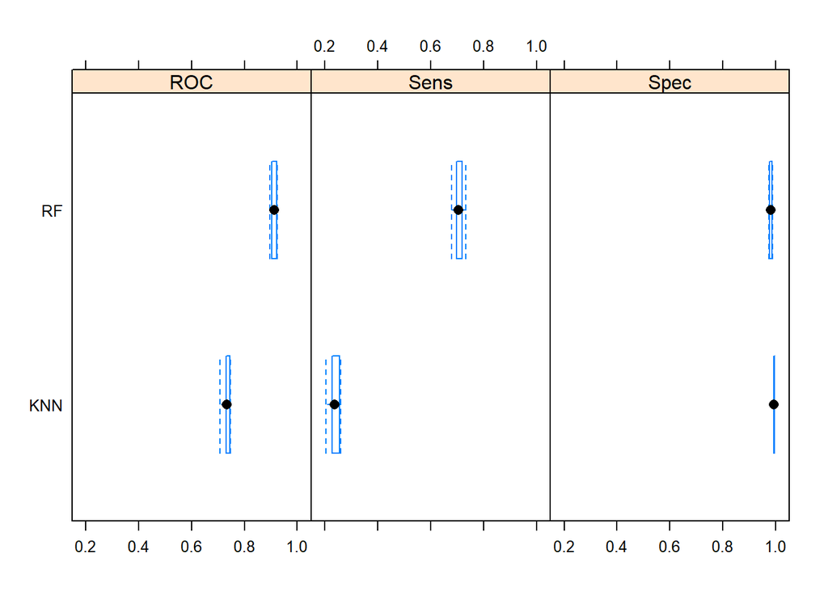

```r
resamps <- resamples(list(RF = rf_m,
                          KNN = knn_m))

theme1 <- trellis.par.get()
theme1$plot.symbol$col = rgb(.2, .2, .2, .4)
theme1$plot.symbol$pch = 16
theme1$plot.line$col = rgb(1, 0, 0, .7)
theme1$plot.line$lwd <- 2
trellis.par.set(theme1)
bwplot(resamps, layout = c(3, 1))
```

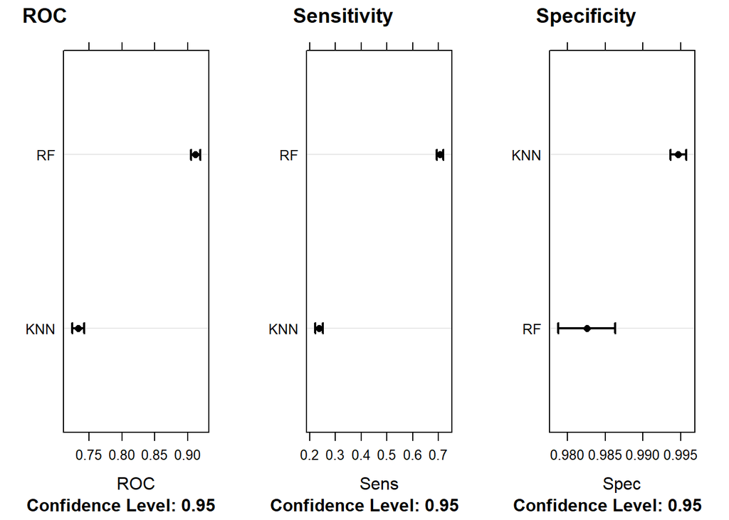

```r
trellis.par.set(caretTheme())
p1 <- dotplot(resamps, metric = "ROC")
p2 <- dotplot(resamps, metric = "Sens")
p3 <- dotplot(resamps, metric = "Spec")


plot_grid(p1, p2, p3, labels=c("ROC", "Sensitivity", "Specificity"), ncol=3, nrow=1)
```

Z wykresów można stwierdzić, że algorytm *Random Forest* radzi sobie odrobinę lepiej od *knn*. W *ROC* oraz *Sensitivity* radzi sobie zauważalnie lepiej. W *Specificity* osiąga odrobinę gorsze wyniki.

# Część 2

## Załaduj zbiór diamonds

```r
data("diamonds")
diam <- diamonds

print(paste("Liczba kolumn: ", ncol(diam)))
```

```
## [1] "Liczba kolumn:  10"
```

```r
print(paste("Liczba wierszy: ", nrow(diam)))
```

```
## [1] "Liczba wierszy:  53940"
```

```r
print("Kolumny:")
```

```
## [1] "Kolumny:"
```

```r
print(colnames(diam))
```

```
##  [1] "carat"   "cut"     "color"   "clarity" "depth"   "table"   "price"
##  [8] "x"       "y"       "z"
```

```r
featuresNames <- setdiff(colnames(diam), c("price"))

rowsWithNA <- which(is.na(diam))
print("Liczba wierszy z brakującymi wartościami: ")
```

```
## [1] "Liczba wierszy z brakującymi wartościami: "
```

```r
print(rowsWithNA)
```

```
## integer(0)
```

```r
kbl(head(diam))  %>%
  kable_material(c("hover"), full_width=F)
```

| carat | cut | color | clarity | depth | table | price | x | y | z |
| --- | --- | --- | --- | --- | --- | --- | --- | --- | --- |
| 0.23 | Ideal | E | SI2 | 61.5 | 55 | 326 | 3.95 | 3.98 | 2.43 |
| 0.21 | Premium | E | SI1 | 59.8 | 61 | 326 | 3.89 | 3.84 | 2.31 |
| 0.23 | Good | E | VS1 | 56.9 | 65 | 327 | 4.05 | 4.07 | 2.31 |
| 0.29 | Premium | I | VS2 | 62.4 | 58 | 334 | 4.20 | 4.23 | 2.63 |
| 0.31 | Good | J | SI2 | 63.3 | 58 | 335 | 4.34 | 4.35 | 2.75 |
| 0.24 | Very Good | J | VVS2 | 62.8 | 57 | 336 | 3.94 | 3.96 | 2.48 |

## Podziel zbiór na uczący i testowy w proporcjach 70%-30%

```r
set.seed(42)
inTraining <- createDataPartition(y=diam$price,
                                  p=0.7,
                                  list=F)
training <- diam[inTraining,]
print(paste("Liczba wierszy zbioru treningowego: ", nrow(training)))
```

```
## [1] "Liczba wierszy zbioru treningowego:  37759"
```

```r
testing <- diam[-inTraining,]
print(paste("Liczba wierszy zbioru tetowego: ", nrow(testing)))
```

```
## [1] "Liczba wierszy zbioru tetowego:  16181"
```

## Stwórz model regresyjny, który przewidzi cenę diamentu na podstawie wartości pozostałych parametrów

Wykorzystany został algorytm regresji liniowej.

```r
ctrl <- trainControl(method = "repeatedcv",
                     number=2,
                     repeats = 5)
lrGrid <- expand.grid(intercept = c(TRUE, FALSE))

lr_m <- train(price ~ .,
             data=training,
             method="lm",
             preProcess = c("center", "scale"),
             trControl = ctrl,
             tuneGrid = lrGrid,
             metric = "RMSE")
print(lr_m)
```

```
## Linear Regression
##
## 37759 samples
##     9 predictor
##
## Pre-processing: centered (23), scaled (23)
## Resampling: Cross-Validated (2 fold, repeated 5 times)
## Summary of sample sizes: 18880, 18879, 18880, 18879, 18879, 18880, ...
## Resampling results across tuning parameters:
##
##   intercept  RMSE      Rsquared   MAE
##   FALSE      4108.046  0.9149404  3955.2601
##    TRUE      1167.226  0.9149404   750.1662
##
## RMSE was used to select the optimal model using the smallest value.
## The final value used for the model was intercept = TRUE.
```

```r
y_pred <- predict(lr_m, newdata=testing)
y_test <- testing[["price"]]

print(paste("Średnia cena to $", round(mean(diam$price), digits=2), " odchylenie standardowe to $", round(sd(diam$price), digits=2), sep=""))
```

```
## [1] "Średnia cena to $3932.8 odchylenie standardowe to $3989.44"
```

```r
print(paste("Błąd RMSE to ", round(rmse(y_test, y_pred), digits=2), sep=""))
```

```
## [1] "Błąd RMSE to 1109.2"
```

Jak widać błąd RMSE jest całkiem duży biorąc pod uwagę zakres cen diamentów. Prawdopodobnie wstępne przetworzenie danych, wybór atrybutów bazując na wykresach przedstawionych w kolejnym punkcie mogłyby poprawić wyniki.

## W trakcie pracy przypatrz się wpływowi różnych zmiennych na cenę diamentu

### Cechy liczbowe

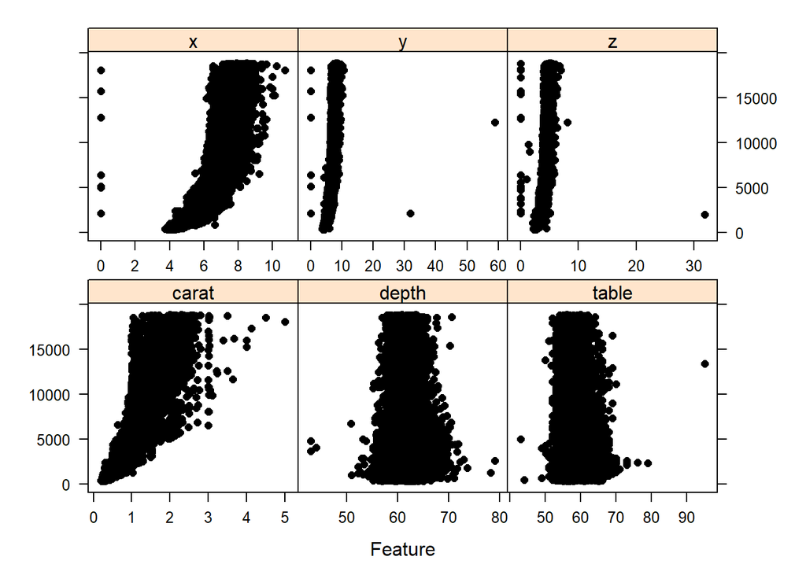

```r
featurePlot(x = diam[, c("carat", "depth", "table", "x", "y", "z")],
            y = diam$price,
            plot = "scatter",
            type = c("p", "scatter"),
            layout = c(3, 2))
```

Na powyższych wykresach zobrazowano jak cechy liczbowe wpływają na cenę diamentów. Na wykresie przedstawiającym zmienną “carat” widać, że im większa wartość zmiennej tym większa cena diamentu. Podobną zależność widać z cechą “x”, jednak wpływa ona trochę mniej na cenę niż “carat”.

### Cechy kategorialne

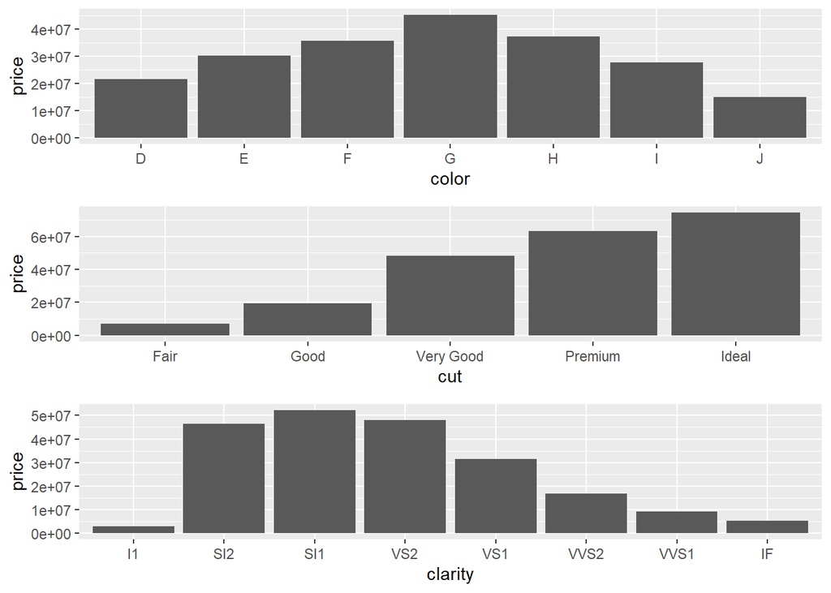

```r
color <- ggplot(diam, aes(x=color, y=price)) +
  geom_col()

cut <- ggplot(diam, aes(x=cut, y=price)) +
  geom_col()

clarity <- ggplot(diam, aes(x=clarity, y=price)) +
  geom_col()

together <- ggarrange(color, cut, clarity, ncol = 1, nrow = 3, common.legend = TRUE, label.x=1)

 print(together)
```